# Data Exploration

Nicholas Mallis

11/11/2021

###Data Exploration The following document loads in the processed data and explores the data creating tables and plots. Here is a list of the tasks completed.

1. Calculating a five number summary for each continuous variable
2. Calculating frequencies and proportions for the one categorical variable
3. Calculating the frequency and percent of missingness among all variables
4. Exploring the distribution of each variable by plotting a histogram for each continuous variable and a bar chart for the one categorical variable.
5. Creating a table of summary statistics for the main text.
6. Creating scatter plots with each continuous predictor and the outcome. Each scatter plot has a linear regression overlay
7. Creating a stratified box plot for our one categorical predictor
8. Mapping vaccination rates by county on the US Map.

Loading packages and then importing processed data

```r
#the following code loads different packages
library(readr) #reading in data
library(plyr) #data wrangling
library(dplyr) #data wrangling
library(here) #setting paths
library(tidyverse) #tidying data
library(gridExtra) #plotting
library(tidyr)#tidying data
library(robustbase) #merging
library(usmap) #plotting map
library(ggplot2) #plotting
library(flextable) #for nice tables


# setting path
data_loc <- here::here("data","processed_data","processeddata.rds")

# reading in data
complete <- readRDS(data_loc)

glimpse(complete)
```

```
## Rows: 3,141
## Columns: 9
## $ FIPS          <dbl> 1001, 1003, 1005, 1007, 1009, 1011, 1013, 1015, 1017, 10…
## $ pct_vax       <dbl> 42.5, 52.2, 44.9, 36.0, 33.2, 52.8, 41.5, 48.8, 32.9, 33…
## $ locality      <chr> "Metro", "Metro", "Non-metro", "Metro", "Metro", "Non-me…
## $ county        <chr> "Autauga County", "Baldwin County", "Barbour County", "B…
## $ state         <chr> "AL", "AL", "AL", "AL", "AL", "AL", "AL", "AL", "AL", "A…
## $ pct_bachelors <dbl> 14.5, 16.8, 11.8, 4.7, 7.0, 10.0, 8.0, 14.2, 8.9, 6.7, 7…
## $ unemployment  <dbl> 4.9, 5.6, 7.0, 6.6, 4.1, 5.5, 8.8, 7.1, 6.8, 4.6, 5.0, 6…
## $ median_income <dbl> 58233, 59871, 35972, 47918, 52902, 31906, 39944, 47747, …
## $ pct_poverty   <dbl> 12.1, 10.1, 27.1, 20.3, 16.3, 30.0, 21.6, 17.2, 19.6, 15…
```

#Exploratory Analysis In the following section, I examine each variable with a five number summary and calculate the percent missing of each variable. I also plot histograms to check the distribution of each variable. For locality, the one categorcial variable, I use a table statement nested within a prop.table to calculate the percentages and plot a stratified frequency chart.

```r
#now let's do a five number summary for each continuous variable
fivenum(complete$pct_vax)
```

```
## [1]  0.1 43.6 51.9 61.1 99.9
```

```r
fivenum(complete$pct_bachelors)
```

```
## [1]  3.7  9.2 11.8 15.6 53.4
```

```r
fivenum(complete$unemployment)
```

```
## [1]  1.7  5.2  6.5  8.0 22.5
```

```r
fivenum(complete$median_income)
```

```
## [1]  24732  46243  53341  62059 151806
```

```r
fivenum(complete$pct_poverty)
```

```
## [1]  2.7 10.4 13.4 17.5 47.7
```

```r
#now let's look at the categorical variable
table(complete$locality)
```

```
##
##     Metro Non-metro
##      1165      1975
```

```r
prop.table(table(complete$locality))
```

```
##
##     Metro Non-metro
## 0.3710191 0.6289809
```

```r
#now let's explore how many and what percent of each variable is missing
Missing <- sapply(complete, function(x) sum(is.na(x)))
Missing
```

```
##          FIPS       pct_vax      locality        county         state
##             0            56             1             0             0
## pct_bachelors  unemployment median_income   pct_poverty
##             8             0             0             0
```

```r
Percent <- 100 * round(colMeans(is.na(complete)), 4)
Percent
```

```
##          FIPS       pct_vax      locality        county         state
##          0.00          1.78          0.03          0.00          0.00
## pct_bachelors  unemployment median_income   pct_poverty
##          0.25          0.00          0.00          0.00
```

```r
Table_Missing <- cbind(Missing, Percent)

#this table will likely end up in the final paper so saved it as a file
missing = here::here("results", "missing.rds")
saveRDS(Table_Missing, file = missing)
```

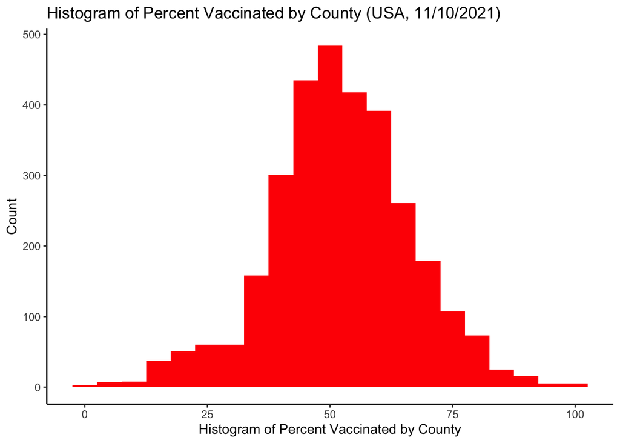

```r
#Now some plotting of distribution for each variable


#here we do % vaccinated
a <- complete %>% ggplot(aes(x=pct_vax)) + geom_histogram(fill="red", binwidth = 5.) + labs(title= "Histogram of Percent Vaccinated by County (USA, 11/10/2021)") + xlab("Histogram of Percent Vaccinated by County") +  ylab("Count") + theme_classic()
a
```

```r
vax_hist = here::here("results","vax_hist.png")
ggsave(filename = vax_hist, plot=a)
```

##Histogram of Main Predictor: Percent With Bachelors Degree The figure below is a histogram of the main predictor variable, percent with a bachelors degree in each county. Here we see that the data is skewed with a tail to the right.

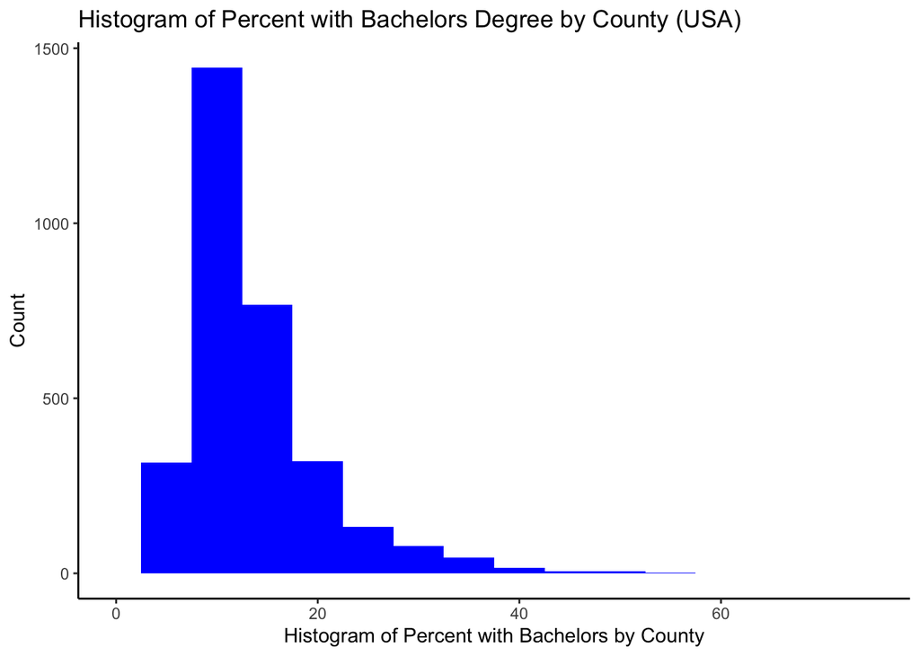

```r
#here we do % bachelors
b <- complete %>% ggplot(aes(x=pct_bachelors)) + geom_histogram(fill="blue", binwidth = 5) + xlim(0, 75) + labs(title= "Histogram of Percent with Bachelors Degree by County (USA)") + xlab("Histogram of Percent with Bachelors by County") +  ylab("Count") + theme_classic()
b
```

```r
bach_hist = here::here("results","bach_hist.png")
ggsave(filename = bach_hist, plot=b)
```

##Histograms of Other Continuous Covariates: Here we can see that the other continuous variables do not appear to be normally distributed. Due to this, we will report medians and IQR’s in our summary statistics table.

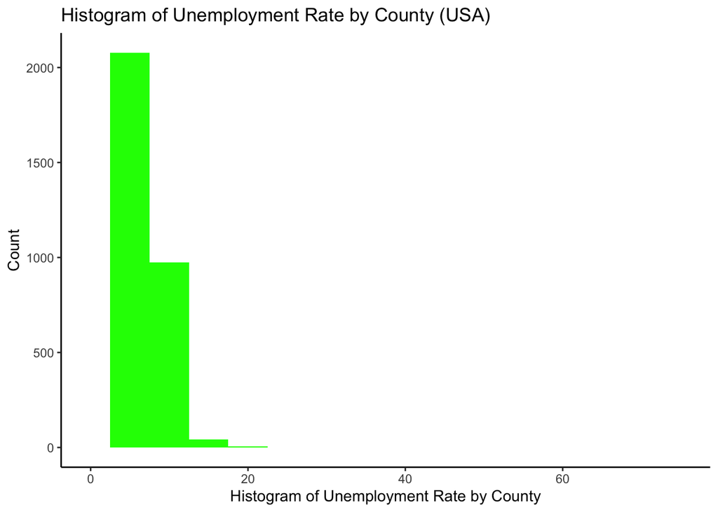

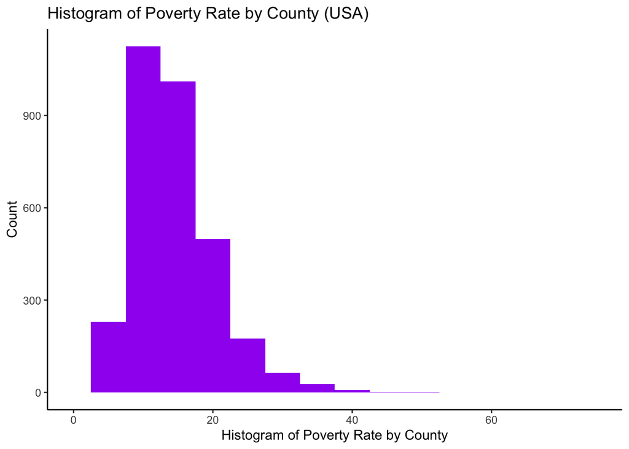

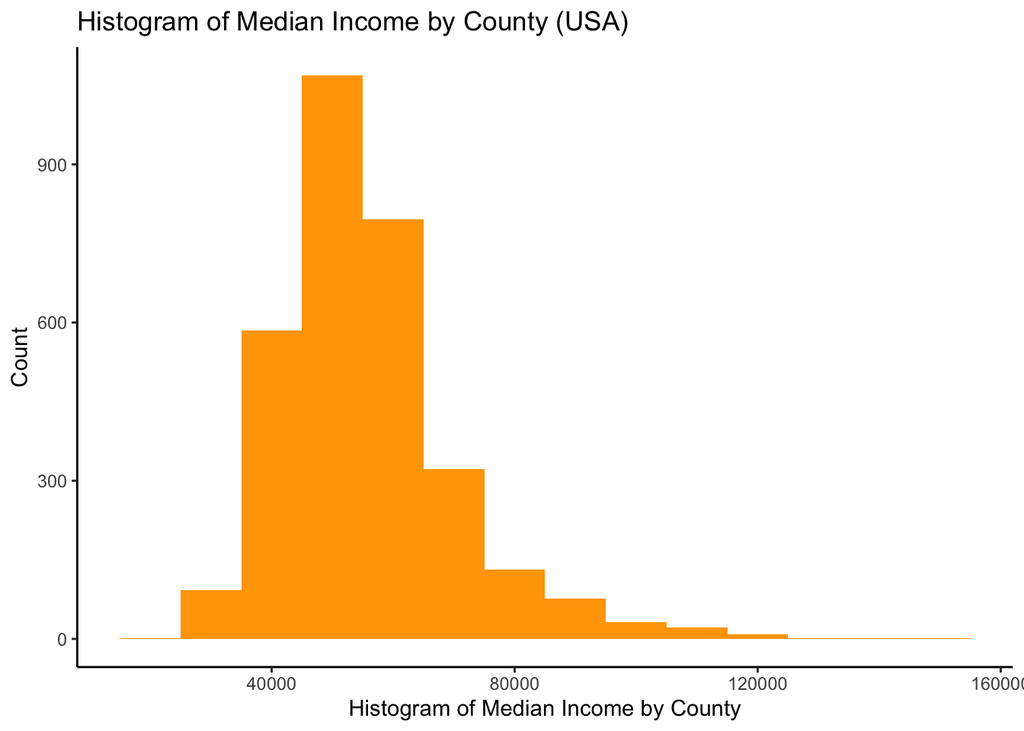

#More Data Management The following code performs some data management in order to summarize each continuous variable.

```r
num_cols <- unlist(lapply(complete, is.numeric))         # identify numeric columns
complete_num <- complete[ , num_cols]                    #subset numeric columns of data



#here use a function to perform multiple calculations on the variables
#to get the median and IQR. notice that I use a transposition to get
#it in working order
table <- as.data.frame( t(sapply(complete_num, function(x) c(
                         "Median" = median(x, na.rm = T),
                          "Min"  =  min(x, na.rm = T),
                          "Max"  = max(x, na.rm = T),
                         "25TH PCT" = unname(quantile(x, 0.25, na.rm = T)),
                         "75TH PCT" = unname(quantile(x, 0.75, na.rm = T)))


)))

#below I do a some more data management to add commas to large figures
table$Median <- prettyNum(table$Median, big.mark = ",", scientific = FALSE)
table$Min <- prettyNum(table$Min, big.mark = ",", scientific = FALSE)
table$Max <- prettyNum(table$Max, big.mark = ",", scientific = FALSE)
table$`25TH PCT` <- prettyNum(table$`25TH PCT`, big.mark = ",", scientific = FALSE)
table$`75TH PCT` <- prettyNum(table$`75TH PCT`, big.mark = ",", scientific = FALSE)

#i also combine the 25th percentile and 75th into a character string seperated by a "-"
table$IQR <- paste(table$`25TH PCT`, table$`75TH PCT`, sep = "-")

#then i add parentheses around it using this function
addparentheses <- function(x){paste("(", x, ")")}
table$IQR <- addparentheses(table$IQR)

# we don't need the first row or middle colums so we delete them
table <- table[ -c(1), -c(4,5)]

rownames(table) <-  c("Percent Vaccinated over 12 years", "Percent with Bachelors Degree or Higher", "Unemployment Rate (%)", "Median Household Income", "Poverty Rate (%)")

tttt <- flextable(table)

tttt
```

| Median | Min | Max | IQR |
| --- | --- | --- | --- |
| 51.9 | 0.1 | 99.9 | ( 43.6-61.1 ) |
| 11.8 | 3.7 | 53.4 | ( 9.2-15.6 ) |
| 6.5 | 1.7 | 22.5 | ( 5.2-8 ) |
| 53,341 | 24,732 | 151,806 | ( 46,243-62,059 ) |
| 13.4 | 2.7 | 47.7 | ( 10.4-17.5 ) |

##Table of Summary Statistics: The table below summarizes the median and interquartile range for each continous variable in the analysis.

```
##                                         Median    Min     Max               IQR
## Percent Vaccinated over 12 years          51.9    0.1    99.9     ( 43.6-61.1 )
## Percent with Bachelors Degree or Higher   11.8    3.7    53.4      ( 9.2-15.6 )
## Unemployment Rate (%)                      6.5    1.7    22.5         ( 5.2-8 )
## Median Household Income                 53,341 24,732 151,806 ( 46,243-62,059 )
## Poverty Rate (%)                          13.4    2.7    47.7     ( 10.4-17.5 )
```

Now I display the saved file for an improved aesthetic.

|  | Median | Min | Max | IQR |
| --- | --- | --- | --- | --- |
| Percent Vaccinated over 12 years | 51.9 | 0.1 | 99.9 | ( 43.6-61.1 ) |
| Percent with Bachelors Degree or Higher | 11.8 | 3.7 | 53.4 | ( 9.2-15.6 ) |
| Unemployment Rate (%) | 6.5 | 1.7 | 22.5 | ( 5.2-8 ) |
| Median Household Income | 53,341 | 24,732 | 151,806 | ( 46,243-62,059 ) |
| Poverty Rate (%) | 13.4 | 2.7 | 47.7 | ( 10.4-17.5 ) |

##Plotting The One Categorical Variable: Locality

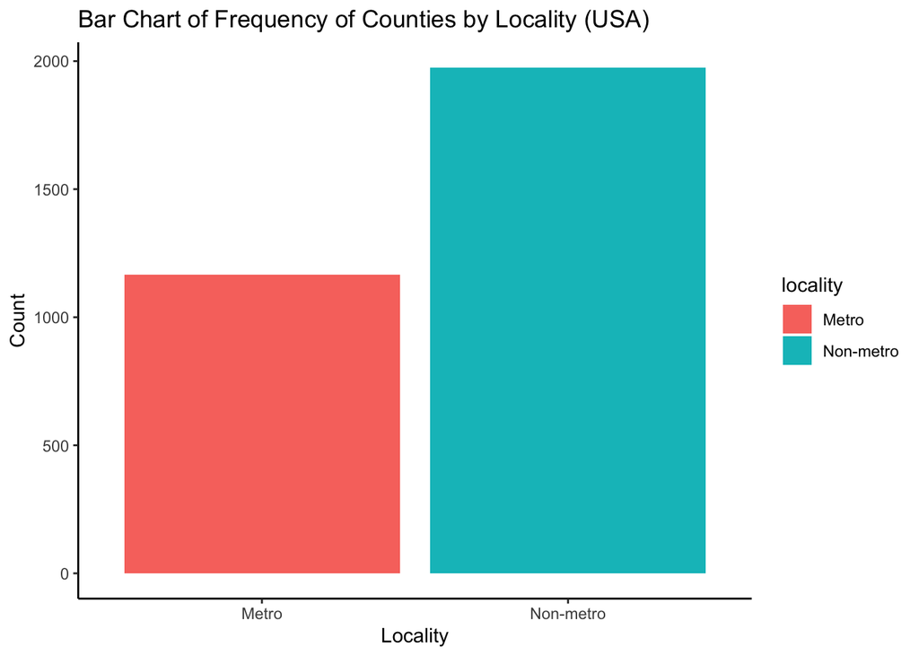

#Further Exploratory Analysis: Main Research Question In the next section, I present scatterplots with linear regression overlays to visualize possible univariate associations between the continuous predictors and outcome. I also present a stratified boxplot by our one categorical predictor, locality. First, I plot percent with bachelors degree or higher vs percent vaccinated. From the scatterplot, we see that there seems to be a positive association. As county bachelors degree percentages increase, percent vaccinated increases.

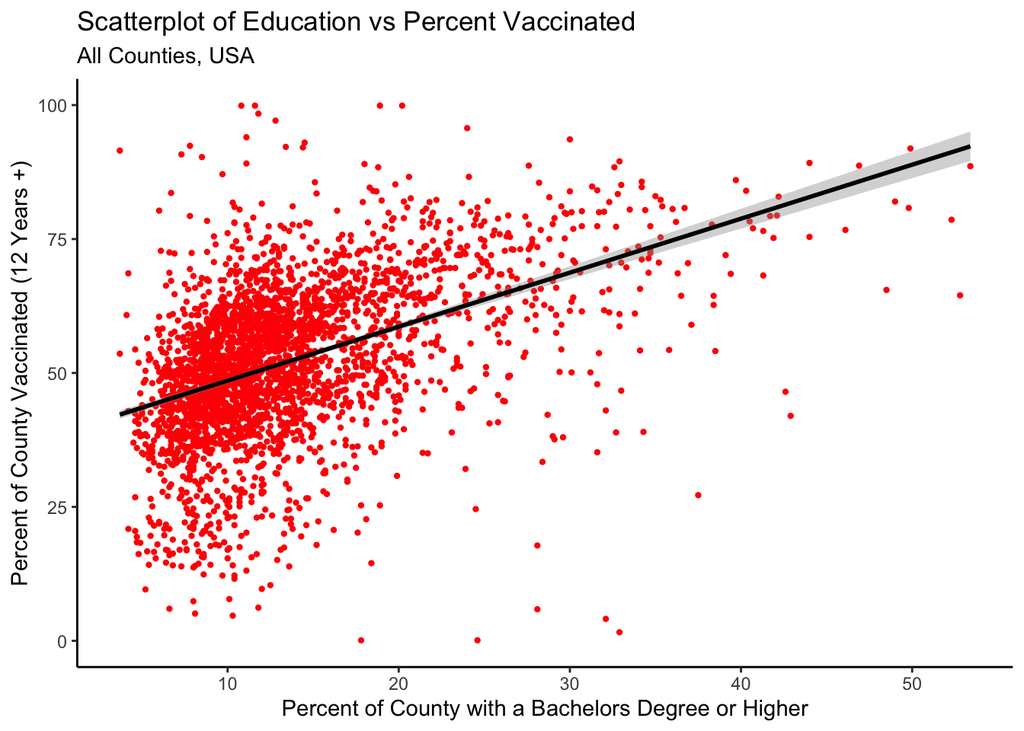

```r
#now let's do a simple scatter plot of our main predictor and outcome to explore the relationship
p1 <- complete %>% ggplot(aes(x=pct_bachelors, y=pct_vax)) + geom_point(color="red", size= .8) + geom_smooth(method='lm', color="black") +
  labs(title= "Scatterplot of Education vs Percent Vaccinated", subtitle = ("All Counties, USA")) + xlab("Percent of County with a Bachelors Degree or Higher") +  ylab("Percent of County Vaccinated (12 Years +)") + theme_classic()

print(p1)
```